# Word Cloud Generator Shiny Application

MM

2024-01-25

# 1. Word Cloud Generator Introduction

This is a proposal for a Word Cloud Generator application, built using Shiny in Rstudio.

- The purpose of this application is to take a text file or text input to generate a Word Cloud.
- It shows the most common words that are in the file or text input.
- The size of each word indicates its frequency or importance.

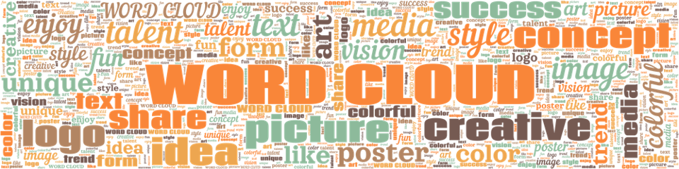

# 2. Word Cloud Generator Input

There are 2 ways that text can be input into the Word Cloud Generator

- First - Choose to type in your own text
- Second - Upload a file with text

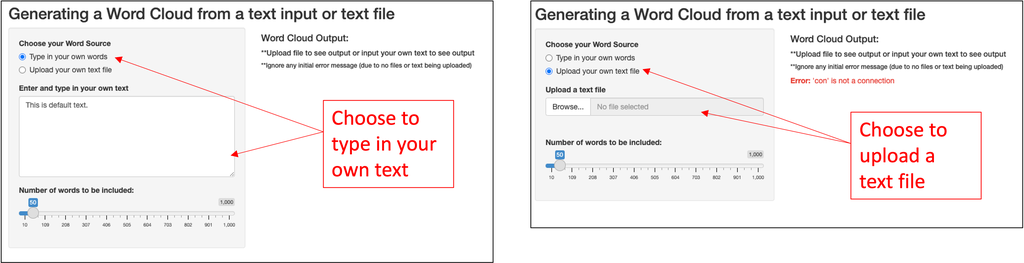

# 3. Word Cloud Generator Output

The Word Cloud output will be auto generated in the main panel.

- Default Text will be shown in case no text or file has been uploaded.

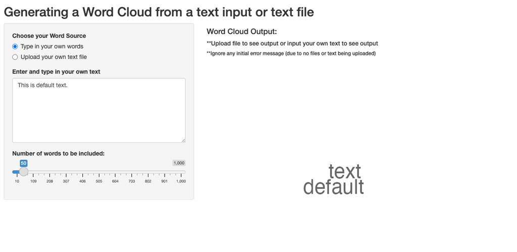

# 4. Actual Output Generated from text

An example of a word cloud generated is shown below.

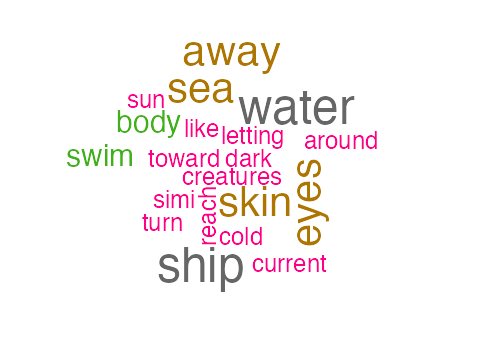

# 5. Help / “About this app” documentation tab

An “About this app” tab is available to give more documentation and to help users on how to use this app.

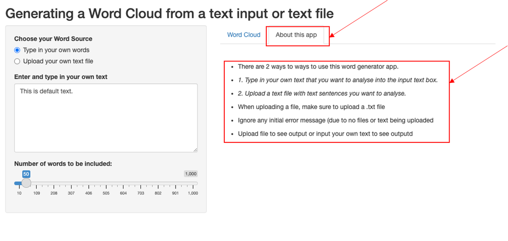

# 6. Summary and Conclusion

- The word cloud generator is very useful as a data product for text analysis.
- It can be used with large amount of text to find words with the highest frequency or importance.

[figure not shown]